# Anirban_INN_Bank_Churn_Full_code

#### EDA Insights

Customer Churn Analysis: Key Findings

This section explores potential factors influencing customer churn through Exploratory Data Analysis (EDA). Our findings reveal several interesting trends:

Demographics:

Gender: There's a higher churn rate among female customers compared to males. This suggests a potential need for targeted customer retention strategies tailored to different genders. Age Group: Churn rate is highest for customers in the 50-60 and 40-50 age groups, while it's lowest for those under 30. This indicates that age might be a risk factor for churn, and efforts to retain older customers could be beneficial. Geography: Churn rates vary significantly across countries. Notably, Germany has the highest rate, followed by Spain and France. This suggests the need for geographically specific churn prevention strategies.

Customer Behavior and Profile:

Number of Products: The number of products held by a customer seems to influence churn. Customers with fewer products tend to churn less, while those with more may have a higher churn risk. Further investigation is needed to understand the specific reasons behind this association. Activity Status: Active customers exhibit a lower churn rate than inactive ones. Fostering customer engagement may be a valuable tactic for retention. Credit Card Ownership: There's no significant difference in churn rate between customers with and without credit cards. This suggests that credit card ownership alone may not be a strong indicator of churn risk. Financial Factors:

Account Balance: Distribution of account balances doesn't show a clear distinction between churned and retained customers. Further analysis and feature engineering could be necessary to explore the potential relationship between balance and churn.

## Data Preprocessing

```python
## Separating Independent and Dependent Columns
X = data.drop(
    ["Exited"],
    axis=1,
)
Y = data["Exited"]
X.columns
```

```
Index(['CreditScore', 'Geography', 'Gender', 'Age', 'Tenure', 'Balance',
       'NumOfProducts', 'HasCrCard', 'IsActiveMember', 'EstimatedSalary'],
      dtype='object')
```

### Dummy Variable Creation

```python
# Encoding the categorical variables using one-hot encoding
X = pd.get_dummies(
    X,
    columns=["Gender", "Geography", "HasCrCard", "IsActiveMember"],
    dtype=int,
    drop_first=True,
)
```

```python
# Standardizing the numerical variables to zero mean and unit variance.
transformer = StandardScaler()
X[["CreditScore", "Age", "Tenure", "Balance", "NumOfProducts", "EstimatedSalary"]] = (
    transformer.fit_transform(
        X[
            [
                "CreditScore",
                "Age",
                "Tenure",
                "Balance",
                "NumOfProducts",
                "EstimatedSalary",
            ]
        ]
    )
)
```

```python
X.columns
```

```
Index(['CreditScore', 'Age', 'Tenure', 'Balance', 'NumOfProducts',
       'EstimatedSalary', 'Gender_Male', 'Geography_Germany',
       'Geography_Spain', 'HasCrCard_1', 'IsActiveMember_1'],
      dtype='object')
```

```python
X.head()
```

|  | CreditScore | Age | Tenure | Balance | NumOfProducts | EstimatedSalary | Gender_Male | Geography_Germany | Geography_Spain | HasCrCard_1 | IsActiveMember_1 |
| --- | --- | --- | --- | --- | --- | --- | --- | --- | --- | --- | --- |
| 0 | -0.326221 | 0.293517 | -1.041760 | -1.225848 | -0.911583 | 0.021886 | 0 | 0 | 0 | 1 | 1 |
| 1 | -0.440036 | 0.198164 | -1.387538 | 0.117350 | -0.911583 | 0.216534 | 0 | 0 | 1 | 0 | 1 |
| 2 | -1.536794 | 0.293517 | 1.032908 | 1.333053 | 2.527057 | 0.240687 | 0 | 0 | 0 | 1 | 0 |
| 3 | 0.501521 | 0.007457 | -1.387538 | -1.225848 | 0.807737 | -0.108918 | 0 | 0 | 0 | 0 | 0 |
| 4 | 2.063884 | 0.388871 | -1.041760 | 0.785728 | -0.911583 | -0.365276 | 0 | 0 | 1 | 1 | 1 |

```python
# X = np.asarray(X).astype(np.float32)
```

### Train-validation-test Split

```python
# Splitting the dataset into the Training and Test set.
X_train, X_test, y_train, y_test = train_test_split(
    X, Y, test_size=0.2, random_state=42, stratify=Y
)
```

```python
# Splitting the Train dataset into the Training and Validation set.
X_train, X_valid, y_train, y_valid = train_test_split(
    X_train, y_train, test_size=0.2, random_state=42, stratify=y_train
)
```

```python
# Printing the shapes.
print(X_train.shape, y_train.shape)
print(X_valid.shape, y_valid.shape)
print(X_test.shape, y_test.shape)
```

```
(6400, 11) (6400,)
(1600, 11) (1600,)
(2000, 11) (2000,)
```

```python
X.columns
```

```
Index(['CreditScore', 'Age', 'Tenure', 'Balance', 'NumOfProducts',
       'EstimatedSalary', 'Gender_Male', 'Geography_Germany',
       'Geography_Spain', 'HasCrCard_1', 'IsActiveMember_1'],
      dtype='object')
```

```python
print(y_train.shape, y_valid.shape, y_test.shape)
```

```
(6400,) (1600,) (2000,)
```

## Model Building

### Model Evaluation Criterion

**A model can make wrong predictions in the following ways:**

- Predicting a customer will leave the bank in the next 6 months but they do not leave..
- Predicting a customer will NOT leave the bank in the next 6 months but they DO leave..

**Which case is more important?**

Predicting a customer will NOT leave the bank in the next 6 months but they DO leave is More Important. Bank cares about retaining the customer and so it is important that we do not make wrong prediction of NOT Leaving while they actually leave

**How to reduce this loss i.e need to reduce False Negatives as well as False Positives?**

So we want to reduce False Negative. Hence Recall is important in this scenario

As we have are dealing with an imbalance in class distribution, we will be using class weights to allow the model to give proportionally more importance to the minority class.

```python
# Calculate class weights for imbalanced dataset
cw = (y_train.shape[0]) / np.bincount(y_train)

# Create a dictionary mapping class indices to their respective class weights
cw_dict = {}
for i in range(cw.shape[0]):
    cw_dict[i] = cw[i]

cw_dict
```

```
{0: 1.2558869701726845, 1: 4.9079754601226995}
```

#### Utility Functions

```python
def plot(history, name):
    """
    Function to plot loss/accuracy

    history: an object which stores the metrics and losses.
    name: can be one of Loss or Accuracy
    """
    fig, ax = plt.subplots()  # Creating a subplot with figure and axes.
    plt.plot(history.history[name])  # Plotting the train accuracy or train loss
    plt.plot(
        history.history["val_" + name]
    )  # Plotting the validation accuracy or validation loss

    plt.title("Model " + name.capitalize())  # Defining the title of the plot.
    plt.ylabel(name.capitalize())  # Capitalizing the first letter.
    plt.xlabel("Epoch")  # Defining the label for the x-axis.
    fig.legend(
        ["Train", "Validation"], loc="outside right upper"
    )  # Defining the legend, loc controls the position of the legend.
```

```python
# defining a function to compute different metrics to check performance of a classification model built using statsmodels
def model_performance_classification(model, predictors, target, threshold=0.5):
    """
    Function to compute different metrics to check classification model performance

    model: classifier
    predictors: independent variables
    target: dependent variable
    threshold: threshold for classifying the observation as class 1
    """

    # checking which probabilities are greater than threshold
    pred = model.predict(predictors) > threshold
    # pred_temp = model.predict(predictors) > threshold
    # # rounding off the above values to get classes
    # pred = np.round(pred_temp)

    acc = accuracy_score(target, pred)  # to compute Accuracy
    recall = recall_score(target, pred, average="weighted")  # to compute Recall
    precision = precision_score(
        target, pred, average="weighted"
    )  # to compute Precision
    f1 = f1_score(target, pred, average="weighted")  # to compute F1-score

    # creating a dataframe of metrics
    df_perf = pd.DataFrame(
        {
            "Accuracy": acc,
            "Recall": recall,
            "Precision": precision,
            "F1 Score": f1,
        },
        index=[0],
    )

    return df_perf
```

```python
def make_confusion_matrix(actual_targets, predicted_targets):
    """
    To plot the confusion_matrix with percentages

    actual_targets: actual target (dependent) variable values
    predicted_targets: predicted target (dependent) variable values
    """
    cm = confusion_matrix(actual_targets, predicted_targets)
    labels = np.asarray(
        [
            ["{0:0.0f}".format(item) + "\n{0:.2%}".format(item / cm.flatten().sum())]
            for item in cm.flatten()
        ]
    ).reshape(cm.shape[0], cm.shape[1])

    plt.figure(figsize=(6, 4))
    sns.heatmap(cm, annot=labels, fmt="")
    plt.ylabel("True label")
    plt.xlabel("Predicted label")
```

```python
train_metric_df = pd.DataFrame(columns=["recall"])
valid_metric_df = pd.DataFrame(columns=["recall"])
```

#### Epoch & Batch size

```python
# defining the batch size and # epochs upfront as we'll be using the same values for all models
epochs = 25
batch_size = 64
```

### NN SGD Optimizer

```python
tf.keras.backend.clear_session()
# Fixing the seed for random number generators so that we can ensure we receive the same output everytime
np.random.seed(2)
random.seed(2)
tf.random.set_seed(2)
```

```python
# Initializing the neural network
model_0 = Sequential()
model_0.add(Dense(32, activation="relu", input_dim=X_train.shape[1]))
model_0.add(Dense(16, activation="relu"))
model_0.add(Dense(1, activation="sigmoid"))
```

```python
model_0.summary()
```

```
Model: "sequential"
_________________________________________________________________
 Layer (type)                Output Shape              Param #
=================================================================
 dense (Dense)               (None, 32)                384

 dense_1 (Dense)             (None, 16)                528

 dense_2 (Dense)             (None, 1)                 17

=================================================================
Total params: 929 (3.63 KB)
Trainable params: 929 (3.63 KB)
Non-trainable params: 0 (0.00 Byte)
_________________________________________________________________
_________________________________________________________________
 Layer (type)                Output Shape              Param #
=================================================================
 dense (Dense)               (None, 32)                384

 dense_1 (Dense)             (None, 16)                528

 dense_2 (Dense)             (None, 1)                 17

=================================================================
Total params: 929 (3.63 KB)
Trainable params: 929 (3.63 KB)
Non-trainable params: 0 (0.00 Byte)
_________________________________________________________________
```

```python
optimizer = tf.keras.optimizers.SGD(0.001)  # defining SGD as the optimizer to be used
metric = keras.metrics.Recall()
model_0.compile(loss="binary_crossentropy", optimizer=optimizer, metrics=[metric])
```

```python
model_0.summary()
```

```
Model: "sequential"
_________________________________________________________________
 Layer (type)                Output Shape              Param #
=================================================================
 dense (Dense)               (None, 32)                384

 dense_1 (Dense)             (None, 16)                528

 dense_2 (Dense)             (None, 1)                 17

=================================================================
Total params: 929 (3.63 KB)
Trainable params: 929 (3.63 KB)
Non-trainable params: 0 (0.00 Byte)
_________________________________________________________________
_________________________________________________________________
 Layer (type)                Output Shape              Param #
=================================================================
 dense (Dense)               (None, 32)                384

 dense_1 (Dense)             (None, 16)                528

 dense_2 (Dense)             (None, 1)                 17

=================================================================
Total params: 929 (3.63 KB)
Trainable params: 929 (3.63 KB)
Non-trainable params: 0 (0.00 Byte)
_________________________________________________________________
```

```python
import time

start = time.time()

history_0 = model_0.fit(
    X_train,
    y_train,
    validation_data=(X_valid, y_valid),
    batch_size=batch_size,
    epochs=epochs,
    class_weight=cw_dict,
)
end = time.time()
```

```python
print("Time taken in seconds ", end - start)
```

```
Time taken in seconds  3.1817188262939453
```

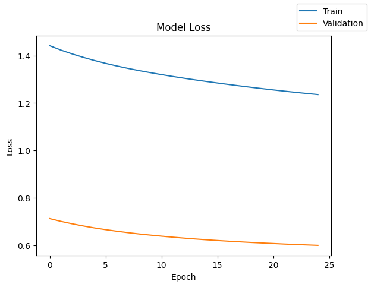

```python
plot(history_0, "loss")
```

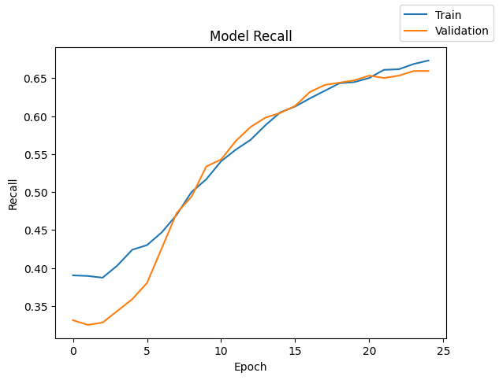

```python
plot(history_0, "recall")
```

```python
model_0_train_perf = model_performance_classification(model_0, X_train, y_train)
model_0_train_perf
```

|  | Accuracy | Recall | Precision | F1 Score |
| --- | --- | --- | --- | --- |
| 0 | 0.685156 | 0.685156 | 0.783067 | 0.713484 |

```python
model_0_valid_perf = model_performance_classification(model_0, X_valid, y_valid)
model_0_valid_perf
```

|  | Accuracy | Recall | Precision | F1 Score |
| --- | --- | --- | --- | --- |
| 0 | 0.67625 | 0.67625 | 0.776306 | 0.705517 |

```python
# Predicting the results using best as a threshold
y_train_pred = model_0.predict(X_train)
y_train_pred = y_train_pred > 0.5
y_train_pred
```

```
array([[ True],
       [False],
       [False],
       ...,
       [False],
       [ True],
       [ True]])
```

```python
# Predicting the results using best as a threshold
y_val_pred = model_0.predict(
    X_valid
)  ## Complete the code to make prediction on the validation set
y_val_pred = y_val_pred > 0.5
y_val_pred
```

```
array([[ True],
       [False],
       [False],
       ...,
       [False],
       [ True],
       [ True]])
```

```python
model_name = "NN with SGD"

train_metric_df.loc[model_name] = recall_score(y_train, y_train_pred)
valid_metric_df.loc[model_name] = recall_score(y_valid, y_val_pred)
```

```python
# classification report
cr = classification_report(y_train, y_train_pred)
print(cr)
```

```
              precision    recall  f1-score   support

           0       0.89      0.69      0.78      5096
           1       0.36      0.68      0.47      1304

    accuracy                           0.69      6400
   macro avg       0.62      0.68      0.62      6400
weighted avg       0.78      0.69      0.71      6400
```

```python
# classification report
cr = classification_report(
    y_valid, y_val_pred
)  ## Complete the code to check the model's performance on the validation set
print(cr)
```

```
              precision    recall  f1-score   support

           0       0.89      0.68      0.77      1274
           1       0.35      0.66      0.45       326

    accuracy                           0.68      1600
   macro avg       0.62      0.67      0.61      1600
weighted avg       0.78      0.68      0.71      1600
```

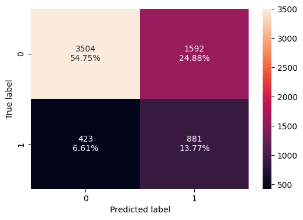

```python
make_confusion_matrix(y_train, y_train_pred)
```

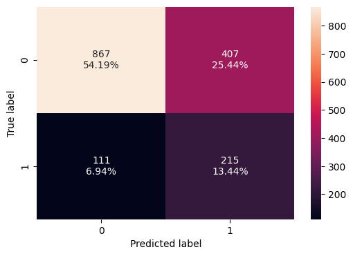

```python
make_confusion_matrix(
    y_valid, y_val_pred
)  ## Complete the code to check the model's performance on the validation set
```

Recall is around 67%. So further improvement is needed

## Model Performance Improvement

### NN Adam Optimizer

```python
# clears the current Keras session, resetting all layers and models previously created, freeing up memory and resources.
tf.keras.backend.clear_session()
np.random.seed(2)
random.seed(2)
tf.random.set_seed(2)
```

```python
# Initializing the neural network
model_1 = Sequential()
model_1.add(Dense(64, activation="relu", input_dim=X_train.shape[1]))
model_1.add(Dense(32, activation="relu"))
model_1.add(Dense(1, activation="sigmoid"))
```

```python
model_1.summary()
```

```
Model: "sequential"
_________________________________________________________________
 Layer (type)                Output Shape              Param #
=================================================================
 dense (Dense)               (None, 64)                768

 dense_1 (Dense)             (None, 32)                2080

 dense_2 (Dense)             (None, 1)                 33

=================================================================
Total params: 2881 (11.25 KB)
Trainable params: 2881 (11.25 KB)
Non-trainable params: 0 (0.00 Byte)
_________________________________________________________________
_________________________________________________________________
 Layer (type)                Output Shape              Param #
=================================================================
 dense (Dense)               (None, 64)                768

 dense_1 (Dense)             (None, 32)                2080

 dense_2 (Dense)             (None, 1)                 33

=================================================================
Total params: 2881 (11.25 KB)
Trainable params: 2881 (11.25 KB)
Non-trainable params: 0 (0.00 Byte)
_________________________________________________________________
```

```python
optimizer = tf.keras.optimizers.Adam()  # defining Adam as the optimizer to be used
metric = keras.metrics.Recall()

model_1.compile(loss="binary_crossentropy", optimizer=optimizer, metrics=[metric])
```

```python
start = time.time()
history_1 = model_1.fit(
    X_train,
    y_train,
    validation_data=(X_valid, y_valid),
    batch_size=batch_size,
    epochs=epochs,
    verbose=1,
)
end = time.time()
```

```python
print("Time taken in seconds ", end - start)
```

```
Time taken in seconds  3.382551431655884
```

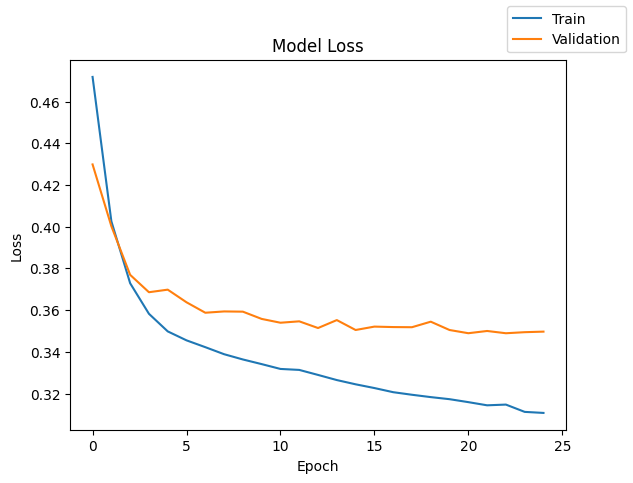

```python
plot(history_1, "loss")
```

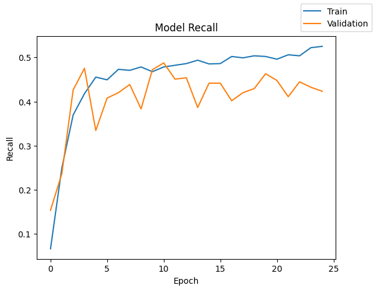

```python
plot(history_1, "recall")
```

```python
model_1_train_perf = model_performance_classification(model_1, X_train, y_train)
model_1_train_perf
```

|  | Accuracy | Recall | Precision | F1 Score |
| --- | --- | --- | --- | --- |
| 0 | 0.875781 | 0.875781 | 0.86934 | 0.865718 |

```python
model_1_valid_perf = model_performance_classification(model_1, X_valid, y_valid)
model_1_valid_perf
```

|  | Accuracy | Recall | Precision | F1 Score |
| --- | --- | --- | --- | --- |
| 0 | 0.8525 | 0.8525 | 0.841553 | 0.836175 |

```python
# Predicting the results using 0.5 as the threshold
y_train_pred = model_1.predict(X_train)
y_train_pred = y_train_pred > 0.5
y_train_pred
```

```
array([[False],
       [False],
       [False],
       ...,
       [False],
       [False],
       [False]])
```

```python
# Predicting the results using 0.5 as the threshold
y_val_pred = model_1.predict(X_valid)
y_val_pred = y_val_pred > 0.5
y_val_pred
```

```
array([[False],
       [False],
       [False],
       ...,
       [False],
       [False],
       [False]])
```

```python
model_name = "NN with Adam"

train_metric_df.loc[model_name] = recall_score(y_train, y_train_pred)
valid_metric_df.loc[model_name] = recall_score(y_valid, y_val_pred)
```

```python
# lassification report
cr = classification_report(y_train, y_train_pred)
print(cr)
```

```
              precision    recall  f1-score   support

           0       0.89      0.97      0.93      5096
           1       0.79      0.53      0.63      1304

    accuracy                           0.88      6400
   macro avg       0.84      0.75      0.78      6400
weighted avg       0.87      0.88      0.87      6400
```

```python
# classification report
cr = classification_report(
    y_valid, y_val_pred
)  ## Complete the code to check the model's performance on the validation set
print(cr)
```

```
              precision    recall  f1-score   support

           0       0.87      0.96      0.91      1274
           1       0.74      0.42      0.54       326

    accuracy                           0.85      1600
   macro avg       0.80      0.69      0.73      1600
weighted avg       0.84      0.85      0.84      1600
```

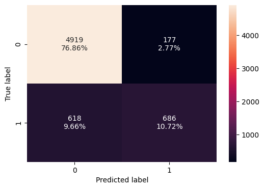

```python
# Calculating the confusion matrix
make_confusion_matrix(y_train, y_train_pred)
```

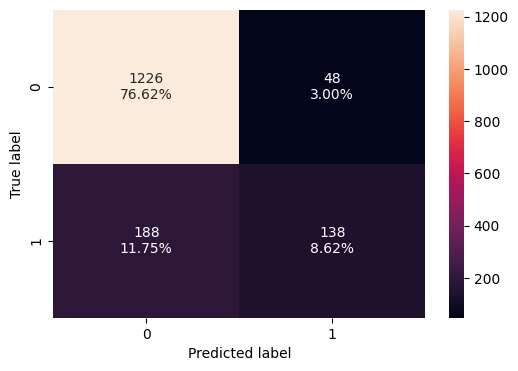

```python
# Calculating the confusion matrix
make_confusion_matrix(y_valid, y_val_pred)
```

### NN Adam Optimizer and Dropout

```python
backend.clear_session()
# Fixing the seed for random number generators so that we can ensure we receive the same output everytime
np.random.seed(2)
random.seed(2)
tf.random.set_seed(2)
```

```python
# Initializing the neural network
model_2 = Sequential()
# Adding the input layer with 32 neurons and relu as activation function
model_2.add(Dense(14, activation="relu", input_dim=X_train.shape[1]))
# Complete the code to add dropout with ratio of 0.2 or any suitable value.
model_2.add(Dropout(0.4))
# Complete the code to add a hidden layer (specify the # of neurons and the activation function)
model_2.add(Dense(7, activation="relu"))
model_2.add(Dropout(0.2))

# Complete the code to add a hidden layer (specify the # of neurons and the activation function)
# Complete the code to add the number of neurons required in the output layer.
model_2.add(Dense(1, activation="sigmoid"))
```

```python
model_2.summary()
```

```
Model: "sequential"
_________________________________________________________________
 Layer (type)                Output Shape              Param #
=================================================================
 dense (Dense)               (None, 14)                168

 dropout (Dropout)           (None, 14)                0

 dense_1 (Dense)             (None, 7)                 105

 dropout_1 (Dropout)         (None, 7)                 0

 dense_2 (Dense)             (None, 1)                 8

=================================================================
Total params: 281 (1.10 KB)
Trainable params: 281 (1.10 KB)
Non-trainable params: 0 (0.00 Byte)
_________________________________________________________________
_________________________________________________________________
 Layer (type)                Output Shape              Param #
=================================================================
 dense (Dense)               (None, 14)                168

 dropout (Dropout)           (None, 14)                0

 dense_1 (Dense)             (None, 7)                 105

 dropout_1 (Dropout)         (None, 7)                 0

 dense_2 (Dense)             (None, 1)                 8

=================================================================
Total params: 281 (1.10 KB)
Trainable params: 281 (1.10 KB)
Non-trainable params: 0 (0.00 Byte)
_________________________________________________________________
```

```python
optimizer = tf.keras.optimizers.Adam()  # defining Adam as the optimizer to be used
model_2.compile(loss="binary_crossentropy", optimizer=optimizer)
```

```python
start = time.time()

history_2 = model_2.fit(
    X_train,
    y_train,
    validation_data=(X_valid, y_valid),
    batch_size=batch_size,
    epochs=epochs,
    class_weight=cw_dict,
)
end = time.time()
```

```python
print("Time taken in seconds ", end - start)
```

```
Time taken in seconds  3.3661491870880127
```

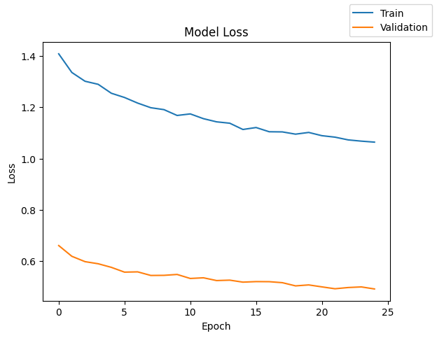

```python
plot(history_2, "loss")
```

```python
model_2_train_perf = model_performance_classification(model_2, X_train, y_train)
model_2_train_perf
```

|  | Accuracy | Recall | Precision | F1 Score |
| --- | --- | --- | --- | --- |
| 0 | 0.791719 | 0.791719 | 0.834308 | 0.805191 |

```python
model_2_valid_perf = model_performance_classification(model_2, X_valid, y_valid)
model_2_valid_perf
```

|  | Accuracy | Recall | Precision | F1 Score |
| --- | --- | --- | --- | --- |
| 0 | 0.776875 | 0.776875 | 0.82589 | 0.792255 |

```python
# Predicting the results using best as a threshold
y_train_pred = model_2.predict(X_train)
y_train_pred = y_train_pred > 0.5
y_train_pred
```

```
array([[ True],
       [False],
       [False],
       ...,
       [False],
       [ True],
       [False]])
```

```python
# Predicting the results using best as a threshold
y_val_pred = model_2.predict(
    X_valid
)  ## Complete the code to make prediction on the validation set
y_val_pred = y_val_pred > 0.5
y_val_pred
```

```
array([[False],
       [False],
       [False],
       ...,
       [False],
       [ True],
       [ True]])
```

```python
model_name = "NN with Adam & Dropout"

train_metric_df.loc[model_name] = recall_score(y_train, y_train_pred)
valid_metric_df.loc[model_name] = recall_score(y_valid, y_val_pred)
```

```python
# classification report
cr = classification_report(y_train, y_train_pred)
print(cr)
```

```
              precision    recall  f1-score   support

           0       0.92      0.81      0.86      5096
           1       0.49      0.73      0.59      1304

    accuracy                           0.79      6400
   macro avg       0.71      0.77      0.72      6400
weighted avg       0.83      0.79      0.81      6400
```

```python
# classification report
cr = classification_report(
    y_valid, y_val_pred
)  ## Complete the code to check the model's performance on the validation set
print(cr)
```

```
              precision    recall  f1-score   support

           0       0.92      0.79      0.85      1274
           1       0.47      0.72      0.57       326

    accuracy                           0.78      1600
   macro avg       0.69      0.76      0.71      1600
weighted avg       0.83      0.78      0.79      1600
```

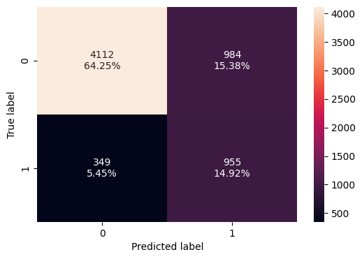

```python
make_confusion_matrix(y_train, y_train_pred)
```

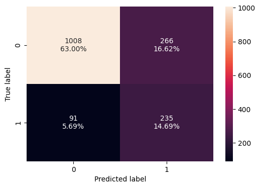

```python
make_confusion_matrix(
    y_valid, y_val_pred
)  ## Complete the code to check the model's performance on the validation set
```